# 02장 다이오드 기본 회로

- 이름: 홍길동
- 학번: 2024123456
- 조: 1

## 공통 코드

```python
import matplotlib.pyplot as plt
import numpy as np
import pandas as pd
import re
import io
from scipy.signal import savgol_filter # 사비츠키-골레이(Savitzky-Golay) 필터
from numpy import nan, inf

# %matplotlib tk
# %matplotlib inline

def tangent_line(f, x):
    h = 1e-4
    d = (f(x+h) - f(x-h)) / (2*h)
    return lambda t: d*t - d*x + f(x)

def tangent_line_end(f, x):
    h = 1e-4
    d = (f(x) - f(x-h)) / (h)
    return lambda t: d*t - d*x + f(x)

def tangent_line_and_gradient(f, x):
    h = 1e-4
    d = (f(x+h) - f(x-h)) / (2*h)
    return (lambda t: d*t - d*x + f(x)), d

def tangent_line_and_gradient_end(f, x):
    h = 1e-4
    d = (f(x) - f(x-h)) / (h)
    return (lambda t: d*t - d*x + f(x)), d

def derivative(f, x):
    h = 1e-4
    d = (f(x+h) - f(x-h)) / (2*h)
    return d

def get_simulation_result(file_name, start=0, end=-1):
    if end == -1:
        end = None
    else:
        end += 1

    with open(file_name, encoding='cp1252') as data_file:
        lines = data_file.read()
        occurrences = lines.count('Step Information:')
        data_file.seek(0)

        line = data_file.readline()
        labels = re.split(', | ,|\t', line)
        labels = [s.strip().upper() for s in labels]

        data = {}

        if (occurrences == 0):
            for label in labels:
                data[label] = []

            for line in data_file:
                values = re.split(', | ,|\t', line)
                for i in range(len(values)):
                    value = float(values[i]) * 1000
                    data[labels[i]].append(value)

        else:
            labels_all =[]

            lines = data_file.readline() # skip first line starting with 'Step Information:'

            for idx in range(occurrences):
                labels_new = []
                for label in labels:
                    labels_new.append('(%s)@%d' % (label, idx+1))
                labels_all += labels_new

                for label_new in labels_new:
                    data[label_new] = []

                for line in data_file:
                    if (line.startswith('Step Information:')):
                        break
                    values = re.split(', | ,|\t', line)
                    for i in range(len(values)):
                        value = float(values[i]) * 1000
                        data[labels_new[i]].append(value)

            labels = labels_all

        for label in labels:
            data[label] = np.array(data[label][start:end])

    # print("labels = ", end='')
    # print(list(data.keys()))
    for label in list(data.keys()):
        print("data['%s'] : sample number = %d" % (label, len(data[label])))

    return data

def get_oscilloscpoe_result_tektronix(file_name, start=0, end=-1):
    if end == -1:
        end = None
    else:
        end += 1

    df = pd.read_csv(file_name, header=None, encoding='cp1252',low_memory=False)

    label_ri = df.loc[df.iloc[:,0] == 'Source', 1].index
    ci = 0
    data = {}
    data['TIME'] = df.iloc[start:end, 3].to_numpy().astype(float)
    data['TIME'] -= data['TIME'][0]
    for idx in range(df.shape[1]//6):
        label = df.iloc[label_ri, ci+1].item()
        data[label] = df.iloc[start:end,ci+4].to_numpy().astype(float)
        ci += 6

    # print("labels = ", end='')
    # print(list(data.keys()))
    for label in list(data.keys()):
        print("data['%s'] : sample number = %d" % (label, len(data[label])))

    return data

def print_array(label, values):
    print('%s = [' % label, end='')
    for idx, vd in enumerate(values):
        print('{:11.3f}'.format(vd), end='')
        if (idx+1 != len(values)):
            print(', ', end='')
    print(']')

def print_value(label, value):
    print('%s = ' % label, end='')
    print('{:11.3f}'.format(value))

def print_value_to_string(label, value):
    output = io.StringIO()
    print('%s = ' % label, end='', file=output)
    print('{:11.3f}'.format(value), file=output)
    captured = output.getvalue()
    return captured

def draw_plot(xs, ys, label, style_idx, color_idx=-1, marker_num=16, scatter=False, scatter_s=2):
    linestyle  = ['-',          '-',            '-',            '-',            '-',
                  '-',          '-',            '-',            '-',            '-',
                  '-',          '-',            '-',            '-',            '-',
                  '-',          '-',            '-',            '-',            '-',
                  '-',          '-',            '-',            '-',            '-']
    colors     = ['blue',       'green',        'red',          'orange',       'purple',
                  'cyan',       'darkseagreen', 'brown',        'goldenrod',    'darkviolet',
                  'steelblue',  'limegreen',    'tomato',       'tan',          'deeppink',
                  'navy',       'lightgreen',   'indianred',    'khaki',        'rebeccapurple',
                  'slategray',  'forestgreen',  'orangered',    'wheat',        'orchid']
    markers    = ['o',          'v',            '<',            's',            'p',
                  'h',          '*',            'X',            'x',            '^',
                  '>',          'P',            'D',            'H',            'd',
                  '|',          '-',            '4'             '5',            '6',
                  '7',          '8',            '9 ',           '10',           '+']

    if color_idx < 0:
        color_idx = style_idx

    if isinstance(xs, list):
        xs = np.array(xs)
    if isinstance(ys, list):
        ys = np.array(ys)

    if (marker_num == 0):
        selected_markevery = None
        selected_marker = None
    elif not isinstance(xs, np.ndarray):
        selected_markevery = None
        selected_marker = markers[style_idx]
    elif (marker_num > 0):
        markeverys = []
        if xs[0] > xs[-1]:
            first_idx = -1
        else:
            first_idx = 0
        x_step = (xs.max() - xs.min()) / marker_num
        for idx in range(len(markers)):
            x_start = xs.min() + ((x_step / (len(markers) + 1)) * idx)
            marker_list = []
            for j in range(marker_num):
                tmp_array = np.where(xs > (x_start + (x_step * j)))
                if (len(tmp_array[0]) > 0):
                    marker_list.append(tmp_array[0][first_idx])
            markeverys.append(marker_list)

        selected_markevery = markeverys[style_idx]
        selected_marker = markers[style_idx]
    else:
        selected_markevery = None
        selected_marker = markers[style_idx]

    if (scatter):
        plt.scatter(xs, ys, color=colors[color_idx], marker=selected_marker, s=scatter_s, label=label)
    else:
        plt.plot(xs, ys, ls=linestyle[style_idx], color=colors[color_idx], marker=selected_marker, markevery=selected_markevery, label=label)
    if (label != None):
        plt.legend(bbox_to_anchor=(1.05, 1), loc='upper left', borderaxespad=0.)

def set_plot_size(xrate, yrate):
    if (len(set_plot_size.g_plt_figsize) == 0):
        set_plot_size.g_plt_figsize = plt.rcParams["figure.figsize"]
    size = []
    size.append(set_plot_size.g_plt_figsize[0] * xrate)
    size.append(set_plot_size.g_plt_figsize[1] * yrate)
    plt.figure(figsize=size)

set_plot_size.g_plt_figsize = []
```

## 실험01 다이오드의 측정 : DMM

### 실험 방법

[figure not shown]

- Si 다이오드 (1N4148)
- Ge 다이오드 (1N270)
- 전원용 다이오드 (1N4004)
- 제너 다이오드 (1N5234)
- LED (빨간색)
- LED (녹색)
- LED (흰색)

### 실험 결과

```python
# 멀티미터 측정 결과가 OL이면 inf로 기록한다.

V_D_S_1N4148_forward_V = 0.564
V_D_S_1N4148_reverse_V = inf

V_D_G_1N270_forward_V = 0.183
V_D_G_1N270_reverse_V = inf

V_D_R_1N4004_forward_V = 0.530
V_D_R_1N4004_reverse_V = inf

V_D_Z_1N5234_forward_V = 0.718
V_D_Z_1N5234_reverse_V = inf

V_D_L_R_forward_V = 1.752
V_D_L_R_reverse_V = inf

V_D_L_G_forward_V = 1.773
V_D_L_G_reverse_V = inf

V_D_L_W_forward_V = inf
V_D_L_W_reverse_V = inf
```

## 실험02 다이오드 전압-전류 특성 측정

### 실험 방법

[figure not shown]

- 저항: 1 kOhm
- 다이오드: 1N4148
- Vi: 직류 0.4 ~ 10 V

### 실험 결과

#### 제작한 회로

[figure not shown]

#### 멀티미터 측정값

```python
V_S_V = [  0.400,  0.600,  0.800,  1.000,  2.000,  3.000,  4.000,  5.000,  6.000,  7.000,  8.000,  9.000, 10.000]

V_I_V = [  0.40 ,  0.60 ,  0.80 ,  1.01 ,  2.02 ,  3.02 ,  4.02 ,  5.02 ,  6.03 ,  7.04 ,  8.06 ,  9.06 ,  10.07]
V_D_V = [  0.395,  0.497,  0.541,  0.564,  0.620,  0.646,  0.663,  0.676,  0.687,  0.695,  0.703,  0.710,  0.716]
```

### 결과 분석

#### 저항 R1의 크기와, 이 저항에 걸리는 전압값을 사용해 다이오드, D1에 흐르는 전류값을 계산한다.

```python
R1_ohm = 1000

V_D_V = np.array(V_D_V)
V_I_V = np.array(V_I_V)

I_D_A = ((V_I_V - V_D_V) / R1_ohm)
I_D_mA = I_D_A * 1000
print_array('I_D_mA', I_D_mA)
```

```
I_D_mA = [      0.005,       0.103,       0.259,       0.446,       1.400,       2.374,       3.357,       4.344,       5.343,       6.345,       7.357,       8.350,       9.354]
```

#### 다이오드의 I<sub>D</sub>-V<sub>D</sub> 특성 곡선을 그린다.

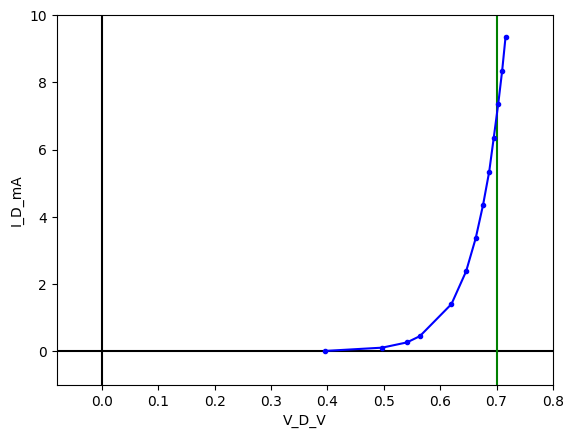

```python
plt.xlabel('V_D_V')
plt.ylabel('I_D_mA')
plt.axhline(0, color='black')
plt.axvline(0, color='black')
plt.axvline(0.7, color='green')
plt.xlim(-0.08,  0.8)
plt.ylim(-1.0, 10.0)
plt.plot(V_D_V, I_D_mA, 'b.-')
plt.show()
```

#### 다이오드 특성 곡선에서 정전압 등가모델용 V<sub>cut_in</sub>을 구한다.

```python
V_cut_in_V = 0.7
print("V_cut_in_V = {:8.3f}".format(V_cut_in_V))
```

```
V_cut_in_V =    0.700
```

#### 다이오드 특성 곡선에서 부분선형 등가모델용 V<sub>cut_in</sub>과 r<sub>D</sub>을 구한다.

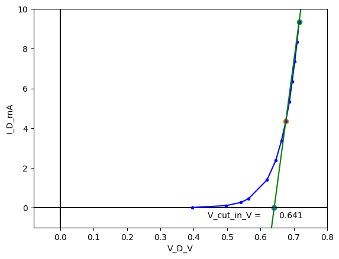

```
Point A: 5.0, 0.676, 4.343999999999999
Point B: 10.0, 0.716, 9.354000000000001

r_D_ohm    =    7.984
V_cut_in_V =    0.641
```

```python
i1 = 7
i2 = 12

xs = V_D_V
ys = I_D_mA

m = (ys[i2] - ys[i1]) / (xs[i2] - xs[i1])
b = ys[i2] - m * xs[i2]
tf = lambda x: m * x + b
gradient = m
txs = np.arange(0.6, 0.8, 0.01)
tys = tf(txs)

V_cut_in_V = np.interp(0.0, tys, txs)
r_D__V_div_mA = 1. / gradient
r_D_ohm = r_D__V_div_mA * 1000.

plt.xlabel('V_D_V')
plt.ylabel('I_D_mA')
plt.axhline(0, color='black')
plt.axvline(0, color='black')
plt.xlim(-0.08,  0.8)
plt.ylim(-1.0, 10.0)
plt.plot(xs, ys, 'b.-')
plt.plot(txs, tys, 'g-')
plt.scatter(V_cut_in_V, 0)
plt.scatter(xs[i1], ys[i1])
plt.scatter(xs[i2], ys[i2])
plt.text(V_cut_in_V-0.2, 0-1.0, print_value_to_string('V_cut_in_V', V_cut_in_V))
plt.show()

print("Point A: {}, {}, {}".format(V_S_V[i1], xs[i1], ys[i1]))
print("Point B: {}, {}, {}".format(V_S_V[i2], xs[i2], ys[i2]))
print()
print("r_D_ohm    = {:8.3f}".format(r_D_ohm))
print("V_cut_in_V = {:8.3f}".format(V_cut_in_V))
```

## 실험03 리미터 회로

### 실험 방법

[figure not shown]

- 저항: 1 kOhm
- 다이오드:
  - Si 다이오드 (1N4148)
  - Ge 다이오드 (1N270)
  - 전원용 다이오드 (1N4004)
  - 제너 다이오드 (1N5234)
  - LED (빨간색)
  - LED (녹색)
  - LED (흰색)
- Vi: 직류 5 V

### 실험 결과

#### 제작한 회로

[figure not shown]

#### 멀티미터 측정값

```python
V_D_S_1N4148_V = 0.677

V_D_G_1N270_V = 0.263

V_D_R_1N4004_V = 0.640

V_D_Z_1N5234_V = 0.775

V_D_L_R_V = 1.922

V_D_L_G_V = 1.952

V_D_L_W_V = 2.649
```

## 실험04 피크검출기 회로

### 실험 방법

[figure not shown]

- 다이오드: 1N4148
- 커패시터: 100 uF
- Vi: 정현파, 주파수 1 kHz, 크기 8 ~ 12 Vpp

### 제작한 회로

[figure not shown]

#### 오실로스코프 화면

##### 8 Vpp

[figure not shown]

##### 10 Vpp

[figure not shown]

##### 12 Vpp

[figure not shown]

##### 8 Vpp

[figure not shown]

### 결과 분석

#### 실험 결과 파일을 읽는다.

```python
data_02_08vpp = get_oscilloscpoe_result_tektronix('./data/ch02_ep04-02_result_08vpp.csv')
data_03_10vpp = get_oscilloscpoe_result_tektronix('./data/ch02_ep04-03_result_10vpp.csv')
data_04_12vpp = get_oscilloscpoe_result_tektronix('./data/ch02_ep04-04_result_12vpp.csv')
data_05_08vpp = get_oscilloscpoe_result_tektronix('./data/ch02_ep04-05_result_08vpp.csv')
```

```
data['TIME'] : sample number = 5208
data['Glitch Capture CH1'] : sample number = 5208
data['Sample CH1'] : sample number = 5208
data['Glitch Capture CH2'] : sample number = 5208
data['Sample CH2'] : sample number = 5208
data['TIME'] : sample number = 5208
data['Glitch Capture CH1'] : sample number = 5208
data['Sample CH1'] : sample number = 5208
data['Glitch Capture CH2'] : sample number = 5208
data['Sample CH2'] : sample number = 5208
data['TIME'] : sample number = 5208
data['Glitch Capture CH1'] : sample number = 5208
data['Sample CH1'] : sample number = 5208
data['Glitch Capture CH2'] : sample number = 5208
data['Sample CH2'] : sample number = 5208
data['TIME'] : sample number = 5208
data['Glitch Capture CH1'] : sample number = 5208
data['Sample CH1'] : sample number = 5208
data['Glitch Capture CH2'] : sample number = 5208
data['Sample CH2'] : sample number = 5208
```

#### 실험 결과에서 시간, 입력 전압, 출력 전압을 가져온다.

```python
times_02_08vpp = data_02_08vpp['TIME']
vins_02_08vpp  = data_02_08vpp['Sample CH1']
vouts_02_08vpp = data_02_08vpp['Sample CH2']

times_03_10vpp = data_03_10vpp['TIME']
vins_03_10vpp  = data_03_10vpp['Sample CH1']
vouts_03_10vpp = data_03_10vpp['Sample CH2']

times_04_12vpp = data_04_12vpp['TIME']
vins_04_12vpp  = data_04_12vpp['Sample CH1']
vouts_04_12vpp = data_04_12vpp['Sample CH2']

times_05_08vpp = data_05_08vpp['TIME']
vins_05_08vpp  = data_05_08vpp['Sample CH1']
vouts_05_08vpp = data_05_08vpp['Sample CH2']
```

#### 필터를 적용해 잡음을 줄인다.

```python
vins_02_08vpp = savgol_filter(vins_02_08vpp, 100, 2)
vouts_02_08vpp = savgol_filter(vouts_02_08vpp, 100, 2)

vins_03_10vpp = savgol_filter(vins_03_10vpp, 100, 2)
vouts_03_10vpp = savgol_filter(vouts_03_10vpp, 100, 2)

vins_04_12vpp = savgol_filter(vins_04_12vpp, 100, 2)
vouts_04_12vpp = savgol_filter(vouts_04_12vpp, 100, 2)

vins_05_08vpp = savgol_filter(vins_05_08vpp, 100, 2)
vouts_05_08vpp = savgol_filter(vouts_05_08vpp, 100, 2)
```

#### 시간을 x축, 전압들을 y축으로 하는 그래프를 그리고, v<sub>O</sub>를 구한다.

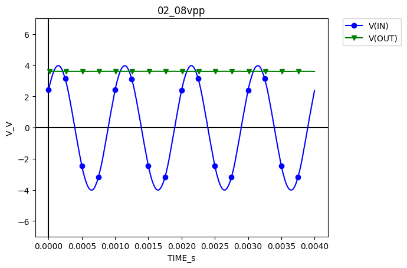

```
V_OUT_mean_V_02_08vpp =       3.601
```

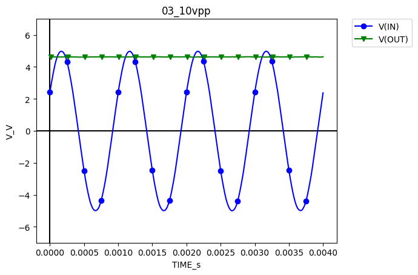

```
V_OUT_mean_V_03_10vpp =       4.619
```

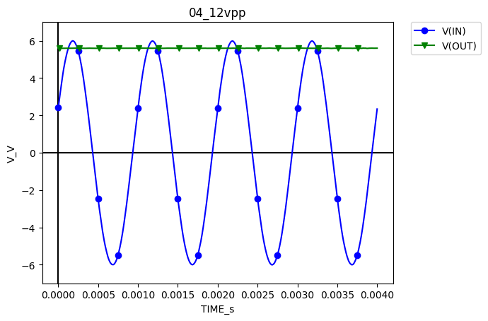

```
V_OUT_mean_V_04_12vpp =       5.595
```

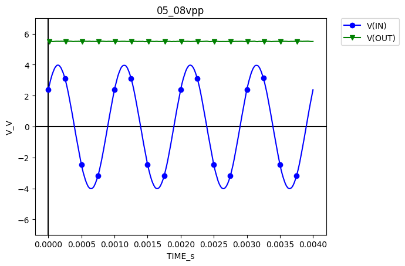

```
V_OUT_mean_V_05_08vpp =       5.502
```

```python
plt.title("02_08vpp")
plt.xlabel('TIME_s')
plt.ylabel('V_V')
plt.axhline(0, color='black')
plt.axvline(0, color='black')
plt.ylim((-7, 7))
draw_plot(times_02_08vpp, vins_02_08vpp, 'V(IN)', 0)
draw_plot(times_02_08vpp, vouts_02_08vpp, 'V(OUT)', 1)
plt.show()

V_OUT_mean_V_02_08vpp = vouts_02_08vpp.mean()
print_value("V_OUT_mean_V_02_08vpp", V_OUT_mean_V_02_08vpp)
print()

plt.title("03_10vpp")
plt.xlabel('TIME_s')
plt.ylabel('V_V')
plt.axhline(0, color='black')
plt.axvline(0, color='black')
plt.ylim((-7, 7))
draw_plot(times_03_10vpp, vins_03_10vpp, 'V(IN)', 0)
draw_plot(times_03_10vpp, vouts_03_10vpp, 'V(OUT)', 1)
plt.show()


V_OUT_mean_V_03_10vpp = vouts_03_10vpp.mean()
print_value("V_OUT_mean_V_03_10vpp", V_OUT_mean_V_03_10vpp)
print()

plt.title("04_12vpp")
plt.xlabel('TIME_s')
plt.ylabel('V_V')
plt.axhline(0, color='black')
plt.axvline(0, color='black')
plt.ylim((-7, 7))
draw_plot(times_04_12vpp, vins_04_12vpp, 'V(IN)', 0)
draw_plot(times_04_12vpp, vouts_04_12vpp, 'V(OUT)', 1)
plt.show()


V_OUT_mean_V_04_12vpp = vouts_04_12vpp.mean()
print_value("V_OUT_mean_V_04_12vpp", V_OUT_mean_V_04_12vpp)
print()

plt.title("05_08vpp")
plt.xlabel('TIME_s')
plt.ylabel('V_V')
plt.axhline(0, color='black')
plt.axvline(0, color='black')
plt.ylim((-7, 7))
draw_plot(times_05_08vpp, vins_05_08vpp, 'V(IN)', 0)
draw_plot(times_05_08vpp, vouts_05_08vpp, 'V(OUT)', 1)
plt.show()

V_OUT_mean_V_05_08vpp = vouts_05_08vpp.mean()
print_value("V_OUT_mean_V_05_08vpp", V_OUT_mean_V_05_08vpp)
print()
```

## 실험05 정류기 회로

### 실험 방법

[figure not shown]

- 다이오드: 1N4004
- 저항: 1 kOhm
- Vi: 정현파, 주파수 1 kHz, 크기 8 Vpp

### 실험 결과

#### 제작한 회로

[figure not shown]

#### 오실로스코프 화면

[figure not shown]

### 결과 분석

#### 실험 결과 파일을 읽는다.

```python
data = get_oscilloscpoe_result_tektronix('./data/ch02_ep05-02_result.csv')
```

```
data['TIME'] : sample number = 5208
data['Glitch Capture CH1'] : sample number = 5208
data['Sample CH1'] : sample number = 5208
data['Glitch Capture CH2'] : sample number = 5208
data['Sample CH2'] : sample number = 5208
```

#### 실험 결과에서 시간, 입력 전압, 출력 전압을 가져온다.

```python
times = data['TIME']
vins = data['Sample CH1']
vouts = data['Sample CH2']
```

#### 필터를 적용해 잡음을 줄인다.

```python
vins = savgol_filter(vins, 100, 2)
vouts = savgol_filter(vouts, 100, 2)
```

#### 시간을 x축, 전압들을 y축으로 하는 그래프를 그린다.

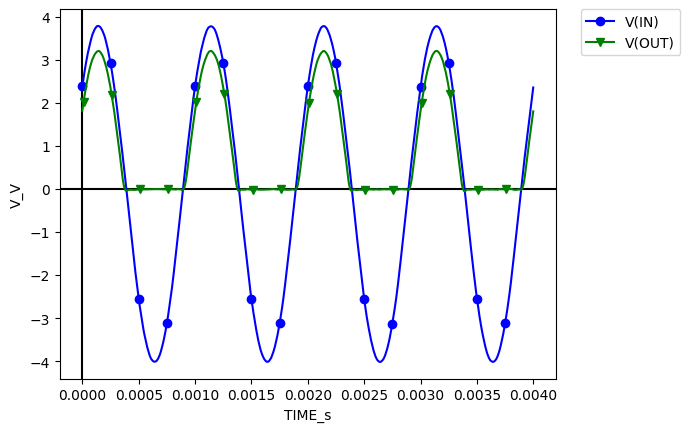

```python
plt.xlabel('TIME_s')
plt.ylabel('V_V')
plt.axhline(0, color='black')
plt.axvline(0, color='black')
draw_plot(times, vins, 'V(IN)', 0)
draw_plot(times, vouts, 'V(OUT)', 1)
plt.show()
```

#### 입력 전압을 x축, 출력 전압을 y축으로 하는 그래프를 그린다.

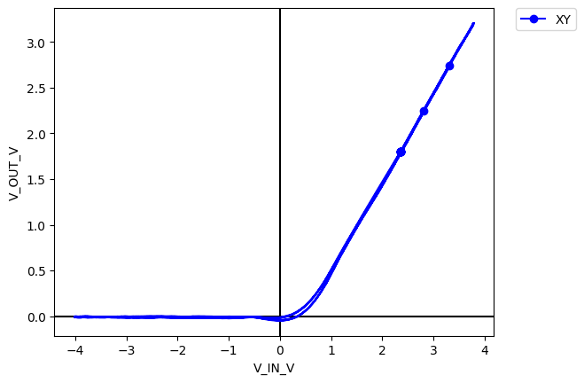

```python
plt.xlabel('V_IN_V')
plt.ylabel('V_OUT_V')
plt.axhline(0, color='black')
plt.axvline(0, color='black')
draw_plot(vins, vouts, "XY", 0)
plt.show()
```